# individual2

Jonathan Kelly

9/9/2020

```r
choco <- read.csv("https://raw.githubusercontent.com/xdaiISU/ds202materials/master/hwlabs/data/choco.csv")
str(choco)
```

```
## 'data.frame':    2312 obs. of  13 variables:
##  $ REF                 : int  2454 2458 2454 797 797 1015 1019 1011 1019 1011 ...
##  $ Company             : Factor w/ 541 levels "5150","A. Morin",..: 1 1 1 2 2 2 2 2 2 2 ...
##  $ Location            : Factor w/ 67 levels "Amsterdam","Argentina",..: 63 63 63 19 19 19 19 19 19 19 ...
##  $ Date                : int  2019 2019 2019 2012 2012 2013 2013 2013 2013 2013 ...
##  $ Bean_Origin         : Factor w/ 63 levels "Australia","Belize",..: 30 14 54 38 5 62 38 16 38 7 ...
##  $ Specific_Bean_Origin: Factor w/ 1436 levels "\"heirloom\", Arriba Nacional",..: 141 1435 666 1029 179 289 267 482 267 189 ...
##  $ Cocoa_Percent       : num  76 76 76 63 70 70 63 70 70 70 ...
##  $ Ingredients         : Factor w/ 21 levels "1- B","2- B,C",..: 5 5 5 10 10 10 5 10 10 10 ...
##  $ Characteristics1    : Factor w/ 450 levels "accesible","accessible",..: 81 81 311 131 430 272 403 328 81 240 ...
##  $ Characteristics2    : Factor w/ 502 levels "","\"Andes\" mint",..: 29 482 137 236 304 301 94 304 408 NA ...
##  $ Characteristics3    : Factor w/ 341 levels "","accessible",..: 115 260 29 251 NA 48 306 66 148 NA ...
##  $ Characteristics4    : Factor w/ 88 levels "acidic","apple",..: NA NA NA NA NA 66 NA 29 NA NA ...
##  $ Rating              : num  3.75 3.5 3.25 3.75 3.5 4 4 3.75 3.5 3.25 ...
```

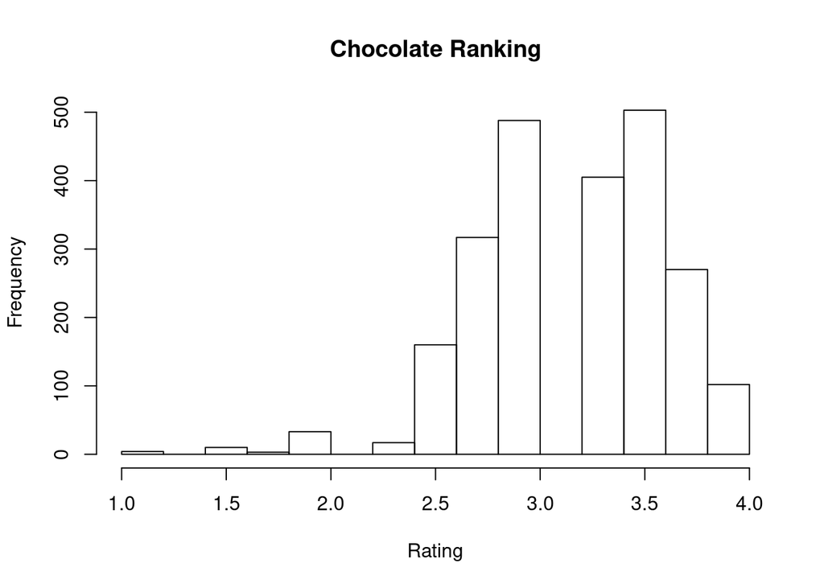

```r
hist(choco$Rating, xlab='Rating', main='Chocolate Ranking')
```

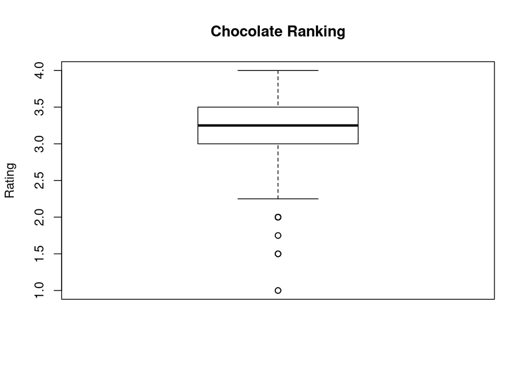

```r
boxplot(choco$Rating, ylab='Rating', main='Chocolate Ranking')
```

How are the ratings distributed? Create both a histogram and a boxplot and describe them. Don’t forget to mention outliers, if there are any.

The ratings are mostly right justified but there a few outliers that ranked very low. There is also a strange hole in the histogram around the 3.1 to 3.2 range.

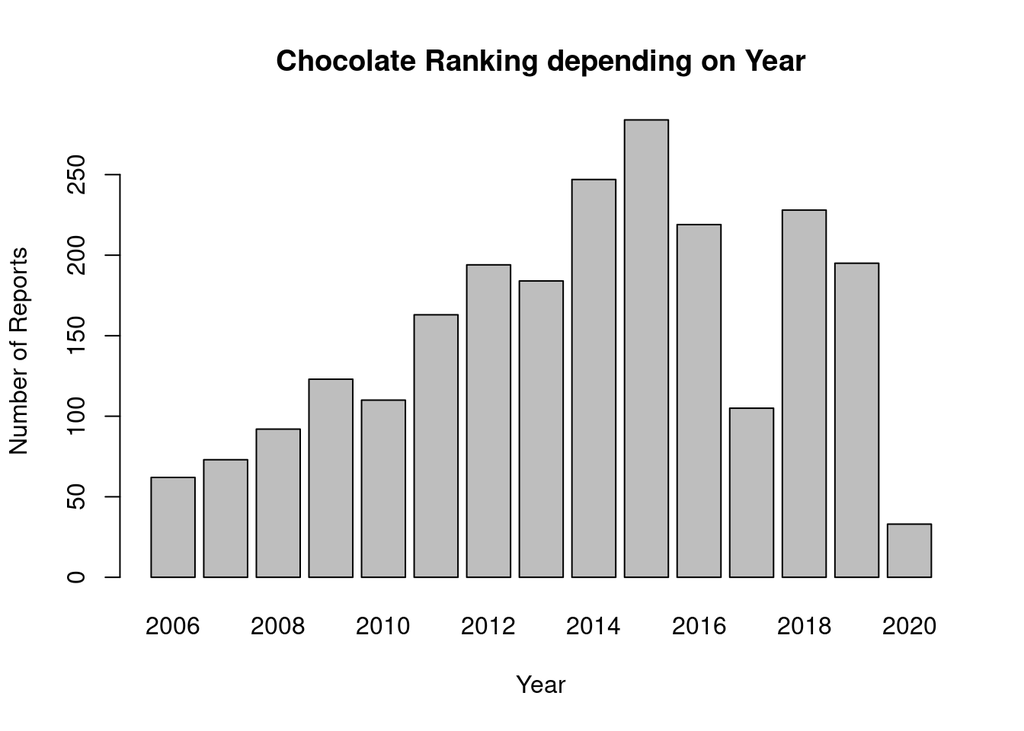

```r
barplot(table(choco$Date), ylab='Number of Reports', xlab='Year', main='Chocolate Ranking depending on Year')
```

How does the number of ratings depend on the year? Draw a bar chart of the number of reports.

The rating start fairly low around 60 in 2006 and slowly increases until it reaches a max at around 270 in 2015 and then begins to decrease again with sharp decreases in 2017 and 2020. But the sharp decrease in 2020 could be attributed to the fact that they are still getting data for the year.

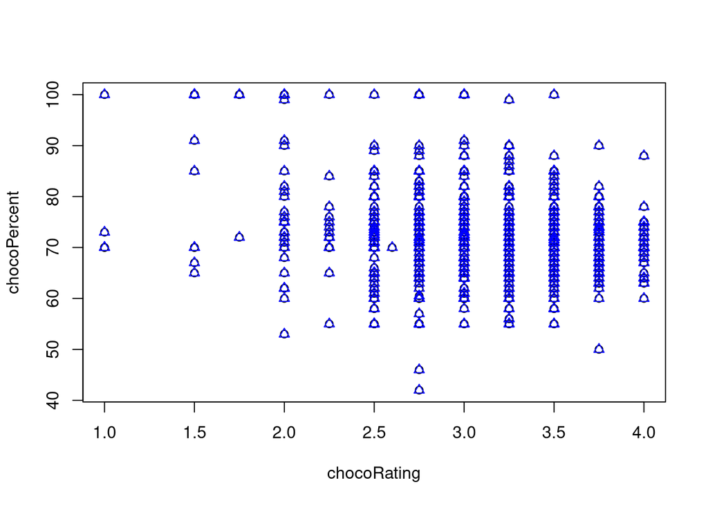

```r
chocoRating <- choco$Rating
chocoPercent <- choco$Cocoa_Percent
plot(chocoRating, chocoPercent)
points(chocoRating, chocoPercent, col='blue', pch=2)
```

```r
cor(chocoRating, chocoPercent)
```

```
## [1] -0.1510178
```

Do ratings depend on the cacao percentage of a chocolate bar? Create both numerical and graphical summaries, and explain.

There is basically no correlation between cacao percentage and the rating of the chocolate bar, the graph is extremely hard to follow and is very hard to follow. The correlation is a -.15 which would be a very weak negative correlation.

```r
charsByRating <- aggregate(choco$Rating, by=list(characteristics=choco$Characteristics1), FUN=mean)
charsByRating2 <- aggregate(choco$Rating, by=list(characteristics=choco$Characteristics2), FUN=mean)
charsByRating3 <- aggregate(choco$Rating, by=list(characteristics=choco$Characteristics3), FUN=mean)
charsByRating4 <- aggregate(choco$Rating, by=list(characteristics=choco$Characteristics4), FUN=mean)
allCharactristicsByRating <- Reduce(function(x, y, w, z) merge(x = x, y = y, w = w, z = z, by = "characteristics", all = TRUE), list(charsByRating, charsByRating2,charsByRating3, charsByRating4))
colnames(allCharactristicsByRating) <- c("characteristics", "rating1", "rating2", "rating3", "rating4")
allCharactristicsByRating$meanRating <- rowMeans(subset(allCharactristicsByRating, select= c(rating1,rating2,rating3,rating4)), na.rm=TRUE)
allCharactristicsByRating <- allCharactristicsByRating[,-c(2:5)]
allCharactristicsByRating <- allCharactristicsByRating[order(allCharactristicsByRating$meanRating),]
allCharactristicsByRating
```

```
##                    characteristics meanRating
## 414          this is not chocolate   1.000000
## 701              strong off flavor   1.000000
## 169          high intensity bitter   1.500000
## 195                         klingy   1.500000
## 698                strong chemical   1.500000
## 731                    very bitter   1.500000
## 838                     unpleasant   1.500000
## 848                            wtf   1.500000
## 520              dominate off note   1.750000
## 837                      unfixable   1.750000
## 26            bitter coffee flavor   2.000000
## 210                        malitol   2.000000
## 256           multiple off flavors   2.000000
## 327                      sandpaper   2.000000
```

[output cut: 836 more lines]

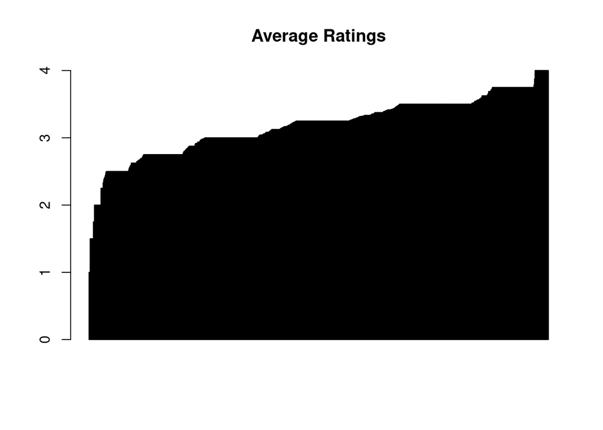

```r
attach(allCharactristicsByRating)
barplot(main = "Average Ratings",  meanRating)
```

```r
worst30 <- allCharactristicsByRating[1:30,]
attach(worst30)
```

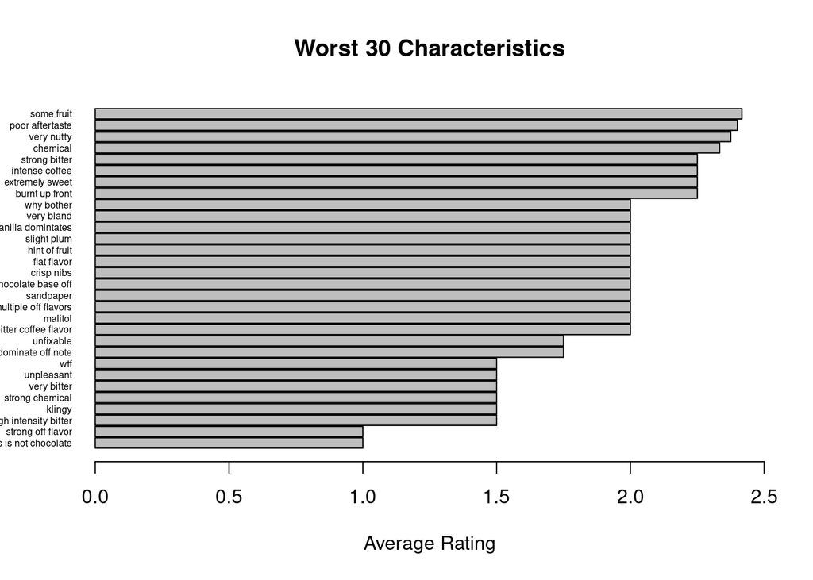

```r
barplot(main = "Worst 30 Characteristics", xlab = "Average Rating", horiz = TRUE, meanRating, names.arg = characteristics, cex.names=0.5, las=1, space=0.1, xlim=c(0,2.5))
```

```r
best30 <- tail(allCharactristicsByRating, n=30)
attach(best30)
```

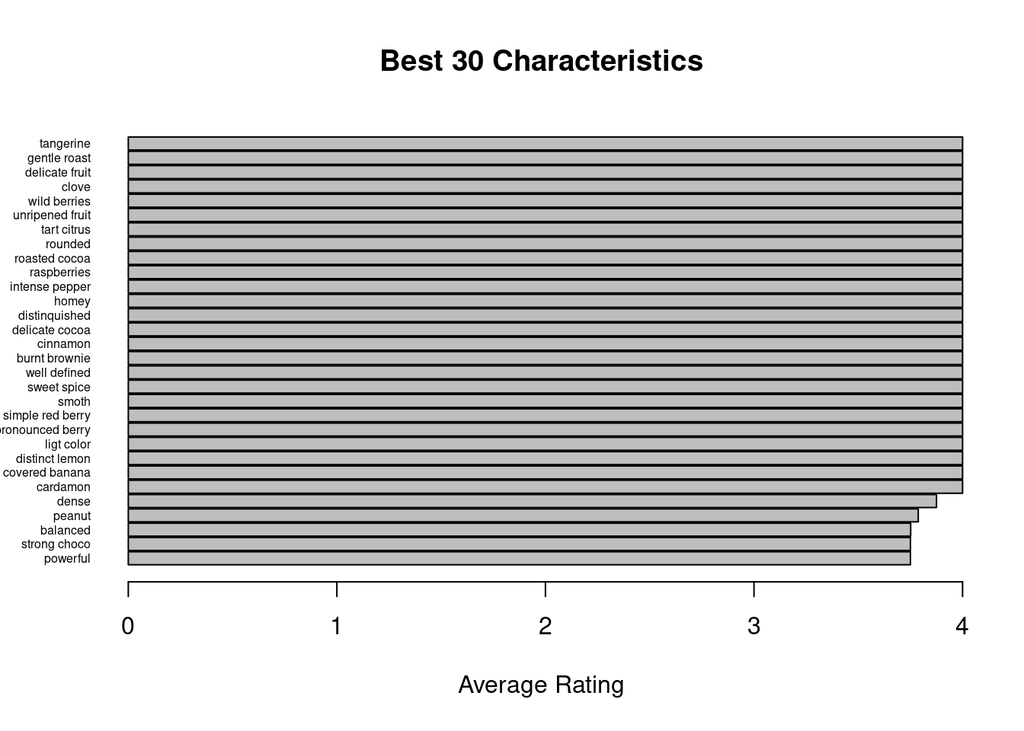

```r
barplot(main = "Best 30 Characteristics", xlab = "Average Rating", horiz = TRUE, meanRating, names.arg = characteristics, cex.names=0.5, las=1, space=0.1 )
```

How do different characteristics of the chocolate compare? To elaborate, which characteristics tend to be more favorable and which ones are not? Create both numerical and graphical summaries, and explain.

I combined all 4 characteristic lists and found the average rating for when ever each characteristic was included for a chocolate bar. I then looked at the top and bottom 30 characteristics with the worst ratings.

“this is not chocolate” and “strong off flavor” were the only 2 characteristics that average score was a 1. There were also other characteristics that understandably scored very low, such as “wtf”, “unpleasant”, “unfixable” and “sandpaper”. Interestingly, “very nutty” is also in the bottom 30 so the judges of these chocolates must not like nuts. Finally there is a sharp increase in scores going from 1 to almost 2.5 fairly quickly.

As for the top 30 chocolates, the top 25 all averaged at the top score of a 4. The smallest average rating of the top 30 is a 3.75 making the range only .25, which is much smaller than the range of the worst 30 chocolates. “tangerine”, “gentle roast”, “delicate fruit”, “clove” and “wild berries” were the top 5 characteristics.

Looking the bar graph of all the chocolates average ratings you can see the sharp increase in scores from 0 to 2.5 and the flat lines every .25 points, as the chocolate from the csv file was all ranked in quarter points.